# Problem Set 2

## About this file

This is the Yicun Duan’s (umich id: 62178151) report of STAT 506’s Problem Set 2. Here is the link to my [GitHub repository](https://github.com/YicunDuanUMich/stats506_hw02).

## Problem 1

### a

**Version 1**

**The code for Problem 1-a Version 1**

```r
rm(list = ls())


#' Simulate the dice game using loop.
#'
#' @param number_of_dice is the number of dice to roll.
#'
#' @return the player's total winnings or loses in integer.
play_dice_loop <- function(number_of_dice) {
  # Check whether the input is smaller than or equal to 0.
  if (number_of_dice <= 0) {
    stop("The input number should be large than 0.")
  }

  # Check whether the input is an integer.
  if(!(all.equal(number_of_dice, round(number_of_dice)) == TRUE)) {
    stop("The number of dice should be an integer.")
  }

  # Randomly roll `number_of_dice` dices.
  roll_results <- sample(1:6, number_of_dice, replace = TRUE)

  # The variable storing the final result.
  total_result <- 0
  # Use a loop to calculate result for each roll.
  for (i in seq_along(roll_results)) {
    roll_result <- roll_results[i]
    # If the roll is of 1, 3 or 5, the player gets no money.
    if (roll_result == 1 ||
        roll_result == 3 ||
        roll_result == 5) {
      # Since each roll costs $2, actually the players will lose $2.
      total_result <- total_result - 2
      next
    }

    # If the roll is of 2, 4 or 6, the player wins the amount on the roll.
    total_result <- total_result + roll_result
    # It costs $2 to play, so we deduct $2 from the `total_result`.
    total_result <- total_result - 2
  }

  return(total_result)
}
```

**Version 2**

**The code for Problem 1-a Version 2**

```r
#' Simulate the dice game using build-in R vectorized functions.
#'
#' @param number_of_dice is the number of dice to roll.
#'
#' @return the player's total winnings or loses in integer.
play_dice_vectorized <- function(number_of_dice) {
  # Check whether the input is smaller than or equal to 0.
  if (number_of_dice <= 0) {
    stop("The input number should be large than 0.")
  }

  # Check whether the input is an integer.
  if(!(all.equal(number_of_dice, round(number_of_dice)) == TRUE)) {
    stop("The number of dice should be an integer.")
  }

  # Randomly roll `number_of_dice` dices.
  roll_results <- sample(1:6, number_of_dice, replace = TRUE)

  # Find the rolls that player loses.
  lose_rolls <- (roll_results == 1) | (roll_results == 3) | (roll_results == 5)

  # When losing, player get no money. Realize this through vectorization.
  roll_results <- roll_results * (!lose_rolls)

  # Each roll costs $2. Realize this through vectorization.
  roll_results <- roll_results - 2

  # Sum it up to get the final result.
  return(sum(roll_results))
}
```

**Version 3**

**The code for Problem 1-a Version 3**

```r
#' Simulate the dice game using `table()`.
#'
#' @param number_of_dice is the number of dice to roll.
#'
#' @return the player's total winnings or loses in integer.
play_dice_table <- function(number_of_dice) {
  # Check whether the input is smaller than or equal to 0.
  if (number_of_dice <= 0) {
    stop("The input number should be large than 0.")
  }

  # Check whether the input is an integer.
  if(!(all.equal(number_of_dice, round(number_of_dice)) == TRUE)) {
    stop("The number of dice should be an integer.")
  }

  # Randomly roll `number_of_dice` dices.
  roll_results <- sample(1:6, number_of_dice, replace = TRUE)

  # Treat `roll_results` as factor, so that `table()` can count the missed number.
  roll_results_factor <- factor(roll_results, levels = 1:6)

  # Get the contingency table of `roll_results_factor`.
  roll_results_table <- table(roll_results_factor)

  # On a roll of 2, 4, or 6, player wins the amount on the roll minus $2.
  # On a roll of 1, 3, or 5, player loses $2.
  roll_results_table <- roll_results_table * c(-2, 0, -2, 2, -2, 4)

  # Sum it up to get the final result.
  return(sum(roll_results_table))
}
```

**Version 4**

**The code for Problem 1-a Version 4**

```r
#' Simulate the dice game using `apply` function.
#'
#' @param number_of_dice is the number of dice to roll.
#'
#' @return the player's total winnings or loses in integer.
play_dice_apply <- function(number_of_dice) {
  # Check whether the input is smaller than or equal to 0.
  if (number_of_dice <= 0) {
    stop("The input number should be large than 0.")
  }

  # Check whether the input is an integer.
  if(!(all.equal(number_of_dice, round(number_of_dice)) == TRUE)) {
    stop("The number of dice should be an integer.")
  }

  # Randomly roll `number_of_dice` dices.
  roll_results <- sample(1:6, number_of_dice, replace = TRUE)

  # Calculate win/lose money for each roll
  roll_results <- vapply(roll_results,
                         function(x) {
                           if (x == 1 ||
                               x == 3 ||
                               x == 5) {
                                return(-2)
                           }
                           return(x - 2)
                         }, 1)

  return(sum(roll_results))
}
```

### b

We test our functions with inputs 3 and 3000:

**The code for Problem 1-b**

```r
# Test version 1
play_dice_loop(3)
```

```
[1] 2
```

**The code for Problem 1-b**

```r
play_dice_loop(3000)
```

```
[1] -168
```

**The code for Problem 1-b**

```r
# Test version 2
play_dice_vectorized(3)
```

```
[1] 4
```

**The code for Problem 1-b**

```r
play_dice_vectorized(3000)
```

```
[1] -190
```

**The code for Problem 1-b**

```r
# Test version 3
play_dice_table(3)
```

```
[1] 6
```

**The code for Problem 1-b**

```r
play_dice_table(3000)
```

```
[1] -38
```

**The code for Problem 1-b**

```r
# Test version 4
play_dice_apply(3)
```

```
[1] 0
```

**The code for Problem 1-b**

```r
play_dice_apply(3000)
```

```
[1] 208
```

### c

In this section, we test whether the outputs of our functions are same:

**The code for Problem 1-c**

```r
# Test version 1
set.seed(1)
loop_3_result <- play_dice_loop(3)
loop_3000_result <- play_dice_loop(3000)

# Test version 2
set.seed(1)
vectorized_3_result <- play_dice_vectorized(3)
vectorized_3000_result <- play_dice_vectorized(3000)

# Test version 3
set.seed(1)
table_3_result <- play_dice_table(3)
table_3000_result <- play_dice_table(3000)

# Test version 4
set.seed(1)
apply_3_result <- play_dice_apply(3)
apply_3000_result <- play_dice_apply(3000)

# Test whether they are equal
print(all(c(loop_3_result, vectorized_3_result,
            table_3_result, apply_3_result)
          == loop_3_result))
```

```
[1] TRUE
```

**The code for Problem 1-c**

```r
print(all(c(loop_3000_result, vectorized_3000_result,
            table_3000_result, apply_3000_result)
          == loop_3000_result))
```

```
[1] TRUE
```

### d

**The code for Problem 1-d**

```r
library(microbenchmark)

benchmark_100 <- microbenchmark(play_dice_loop(100),
                                 play_dice_vectorized(100),
                                 play_dice_table(100),
                                 play_dice_apply(100))

benchmark_10000 <- microbenchmark(play_dice_loop(10000),
                                 play_dice_vectorized(10000),
                                 play_dice_table(10000),
                                 play_dice_apply(10000))
benchmark_100
```

```
Unit: microseconds
                      expr  min    lq   mean median   uq   max neval
       play_dice_loop(100) 23.2 24.30 26.185  24.70 26.0  60.3   100
 play_dice_vectorized(100) 19.3 20.35 24.492  21.40 23.3 114.6   100
      play_dice_table(100) 42.4 44.65 51.841  46.95 52.6 143.1   100
      play_dice_apply(100) 56.6 58.20 60.942  59.30 62.2  92.4   100
```

**The code for Problem 1-d**

```r
benchmark_10000
```

```
Unit: microseconds
                        expr    min     lq     mean  median      uq    max
       play_dice_loop(10000)  917.7  950.2  975.781  966.25  983.15 1118.7
 play_dice_vectorized(10000)  529.1  610.8  628.842  619.60  636.50  959.6
      play_dice_table(10000)  623.2  723.1  760.651  744.65  770.45 1267.4
      play_dice_apply(10000) 3997.6 4086.8 4400.738 4193.20 4395.05 6331.0
 neval
   100
   100
   100
   100
```

### e

**The code for Problem 1-d**

```r
n <- 1000
per_roll_times <- 100

simu_results <- vector("double", length = n)

for (i in 1:n) {
  simu_results[i] <- play_dice_vectorized(per_roll_times) / per_roll_times
}

# theta_hat = sum_{i=1}^{n} X_i / n
theta_hat <- sum(simu_results) / n

# sigma = standard deviation of X_i
sigma <- sd(simu_results)

alpha <- 0.05

confi_bound_low <- theta_hat - sigma / sqrt(n) * qt(1.0 - alpha / 2, df = n - 1)
confi_bound_high <- theta_hat + sigma / sqrt(n) * qt(1.0 - alpha / 2, df = n - 1)

confi_bound_low_round <- round(confi_bound_low, 3)
confi_bound_high_round <- round(confi_bound_high, 3)

cat("Lower confidence bound: ",
    confi_bound_low_round,
    "\nHigher confidence bound:",
    confi_bound_high_round,
    "\n(alpha=", alpha, ")")
```

```
Lower confidence bound:  -0.02
Higher confidence bound: 0.008
(alpha= 0.05 )
```

As shown in our Monte Carlo simulation, when we roll the dice for $1000 \times 100$ times and set $\alpha$ to be 0.05, we can get the confidence interval (-0.02, 0.008) which covers 0. Therefore, we can conclude that this is a fair game.

**Clear environment**

```r
rm(list = ls())
```

## Problem 2

### a

We load the data from file and rename the columns.

**The code for Problem 2-a**

```r
cars_data <- read.table("./data/cars.csv", sep = ",", header = TRUE)
names(cars_data) <- c("H", "L", "W",
                      "driveline",
                      "engine_type", "hybrid", "gears",
                      "transmission",
                      "city_mpg", "fuel_type", "highway_mpg",
                      "classification",
                      "id", "make",
                      "model_year", "year",
                      "horsepower", "torque")
```

### b

We only consider the cars whose fuel type is Gasoline.

**The code for Problem 2-b**

```r
cars_data <- cars_data[cars_data$fuel_type == "Gasoline", ]
```

### c

**The code for Problem 2-c**

```r
cars_data$year <- as.factor(cars_data$year)

highway_mpg_horsepower_model <- lm(highway_mpg ~ horsepower +
                                     torque + H + W + L + year,
                                   data = cars_data)
summary(highway_mpg_horsepower_model)
```

```
Call:
lm(formula = highway_mpg ~ horsepower + torque + H + W + L +
    year, data = cars_data)

Residuals:
    Min      1Q  Median      3Q     Max
-10.824  -2.550  -0.452   2.372 202.639

Coefficients:
              Estimate Std. Error t value Pr(>|t|)
(Intercept) 32.2926630  0.7225982  44.690  < 2e-16 ***
horsepower   0.0163556  0.0022772   7.182 7.96e-13 ***
torque      -0.0507425  0.0022030 -23.034  < 2e-16 ***
H            0.0099079  0.0011267   8.794  < 2e-16 ***
W           -0.0003343  0.0009045  -0.370   0.7117
L            0.0017290  0.0008836   1.957   0.0504 .
year2010    -0.4539681  0.6768246  -0.671   0.5024
year2011     0.1711016  0.6757043   0.253   0.8001
year2012     1.3029279  0.6810076   1.913   0.0558 .
---
Signif. codes:  0 '***' 0.001 '**' 0.01 '*' 0.05 '.' 0.1 ' ' 1

Residual standard error: 4.602 on 4582 degrees of freedom
Multiple R-squared:  0.4192,    Adjusted R-squared:  0.4182
F-statistic: 413.3 on 8 and 4582 DF,  p-value: < 2.2e-16
```

From the summary of our regression model, we find that the estimated coefficient of `horsepower` is 0.0163556, its deviation is 0.0022772, t value is 7.182 and p value is 7.96e-13. This demonstrates that there is a relationship between `horsepower` and `highway_mpg`, since the small p value ($< 0.05$) can help us reject the null hypothesis. The positive slope of `horsepower` also shows that, when the `horsepower` increases by 1 unit, the `highway_mpg` will also grow by about 0.0163556 unit. The summary also showcases other important statistical value. The $R^2$ value (0.4192) indicates that about $41.92\%$ variability of `highway_mpg` can be explained by the predictors (like `horsepower`, `torque` and `L`). The p value of F test shows that the predictors play an important role in building up this regression model.

### d

**The code for Problem 2-c**

```r
library(emmeans)

highway_mpg_horsepower_with_torque_model <- lm(highway_mpg ~ horsepower * torque +
                                                              H + W + L + year, data = cars_data)
summary(highway_mpg_horsepower_with_torque_model)
```

```
Call:
lm(formula = highway_mpg ~ horsepower * torque + H + W + L +
    year, data = cars_data)

Residuals:
    Min      1Q  Median      3Q     Max
-11.109  -2.313  -0.258   2.062 203.540

Coefficients:
                    Estimate Std. Error t value Pr(>|t|)
(Intercept)        4.219e+01  7.930e-01  53.199  < 2e-16 ***
horsepower        -1.666e-02  2.539e-03  -6.563 5.84e-11 ***
torque            -8.606e-02  2.533e-03 -33.972  < 2e-16 ***
H                  6.560e-03  1.070e-03   6.133 9.32e-10 ***
W                 -1.169e-03  8.521e-04  -1.372   0.1700
L                  1.777e-03  8.318e-04   2.136   0.0327 *
year2010          -5.628e-01  6.372e-01  -0.883   0.3771
year2011           7.254e-02  6.361e-01   0.114   0.9092
year2012           1.197e+00  6.411e-01   1.867   0.0619 .
horsepower:torque  1.124e-04  4.628e-06  24.276  < 2e-16 ***
---
Signif. codes:  0 '***' 0.001 '**' 0.01 '*' 0.05 '.' 0.1 ' ' 1

Residual standard error: 4.333 on 4581 degrees of freedom
Multiple R-squared:  0.4854,    Adjusted R-squared:  0.4844
F-statistic: 480.1 on 9 and 4581 DF,  p-value: < 2.2e-16
```

**The code for Problem 2-c**

```r
summary(cars_data$horsepower)
```

```
   Min. 1st Qu.  Median    Mean 3rd Qu.    Max.
  100.0   185.0   263.0   267.5   317.0   638.0
```

**The code for Problem 2-c**

```r
summary(cars_data$torque)
```

```
   Min. 1st Qu.  Median    Mean 3rd Qu.    Max.
   98.0   177.0   257.0   267.2   332.0   774.0
```

**The code for Problem 2-c**

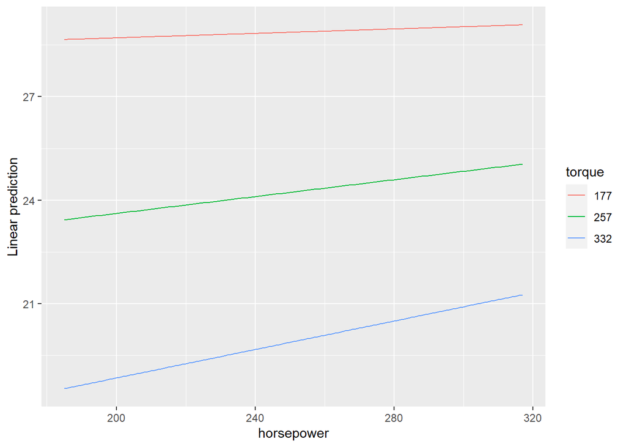

```r
emmip(highway_mpg_horsepower_with_torque_model, torque ~ horsepower, at = list(horsepower = 185:317, torque = c(177, 257, 332), year = "2011"))
```

As shown in the above figure, we draw the regression lines of `highway_mpg` v.s. `horsepower` while controlling the `torque` to be 177, 257 and 332. These three torque values are the 1Q, Median and 3Q of `torque`. The values of `horsepower` are also selected from interval (1Q, 3Q).

### e

We first extract the design matrix from the model and then calculate the $\hat{\beta}$. The testing shows that our manually calculated $\hat{\beta}$ is the same as that of `lm`.

**The code for Problem 2-c**

```r
design_matrix <- model.matrix(highway_mpg_horsepower_with_torque_model)
y <- model.frame(highway_mpg_horsepower_with_torque_model)[, 1]

xt_x <- t(design_matrix) %*% design_matrix
xt_x_i <- solve(xt_x)
beta <- xt_x_i %*% t(design_matrix) %*% y

summary_highway_mpg_horsepower_with_torque_model <- summary(highway_mpg_horsepower_with_torque_model)

for (i in seq_along(beta)) {
  print(all.equal(beta[i], summary_highway_mpg_horsepower_with_torque_model$coefficients[i, 1]) == TRUE)
}
```

```
[1] TRUE
[1] TRUE
[1] TRUE
[1] TRUE
[1] TRUE
[1] TRUE
[1] TRUE
[1] TRUE
[1] TRUE
[1] TRUE
```

**The code for Problem 2-c**

```r
rm(list = ls())
```

## Problem 3

We import data from file and rename the columns.

### a

```stata
. // Import the csv file.
. import delimited "K:\data\cars.csv"
(encoding automatically selected: ISO-8859-1)
(18 vars, 5,076 obs)

. // Open the browser.
. browse *

.
. // Rename the columns.
. rename dimensionsheight H

. rename dimensionslength L

. rename dimensionswidth W

. rename engineinformationdriveline driveline

. rename engineinformationenginetype engine_type

. rename engineinformationhybrid hybrid

. rename engineinformationnumberofforward gears

. rename engineinformationtransmission transmission

. rename fuelinformationcitympg city_mpg

. rename fuelinformationfueltype fuel_type

. rename fuelinformationhighwaympg highway_mpg

. rename identificationclassification classification

. rename identificationid id

. rename identificationmake make

. rename identificationmodelyear model_year

. rename identificationyear year

. rename engineinformationenginestatistic horsepower

. rename v18 torque
```

### b

We drop the data whose fuel type is not Gasoline.

```stata
. // Restrict the data to cars whose Fuel Type is "Gasoline".
. keep if fuel_type == "Gasoline"
(485 observations deleted)
```

### c

We fit a model to find the relationship between `highway_mpg` and `horsepower`.

```stata
. // Fit a linear regression model predicting MPG on the highway with horsepower as predictor.
. regress highway_mpg c.horsepower c.torque c.H c.L c.W i.year

      Source |       SS           df       MS      Number of obs   =     4,591
-------------+----------------------------------   F(8, 4582)      =    413.35
       Model |  70043.6695         8  8755.45869   Prob > F        =    0.0000
    Residual |   97055.298     4,582  21.1818634   R-squared       =    0.4192
-------------+----------------------------------   Adj R-squared   =    0.4182
       Total |  167098.968     4,590  36.4050038   Root MSE        =    4.6024

------------------------------------------------------------------------------
 highway_mpg | Coefficient  Std. err.      t    P>|t|     [95% conf. interval]
-------------+----------------------------------------------------------------
  horsepower |   .0163556   .0022772     7.18   0.000     .0118913      .02082
      torque |  -.0507425    .002203   -23.03   0.000    -.0550614   -.0464236
           H |   .0099079   .0011267     8.79   0.000      .007699    .0121168
           L |    .001729   .0008836     1.96   0.050    -3.36e-06    .0034613
           W |  -.0003343   .0009045    -0.37   0.712    -.0021075    .0014388
             |
        year |
       2010  |  -.4539681   .6768246    -0.67   0.502     -1.78087    .8729342
       2011  |   .1711016   .6757043     0.25   0.800    -1.153604    1.495808
       2012  |   1.302928   .6810076     1.91   0.056    -.0321751    2.638031
             |
       _cons |   32.29266   .7225982    44.69   0.000     30.87602     33.7093
------------------------------------------------------------------------------

.
```

As displayed in Stata’s output, the estimated coefficient of `horsepower` is 0.0163556, which indicates that the one unit increment on `horsepower` will bring about 0.0163556 unit increment on `highway_mpg`. The p value of `horsepower` (0.000) demonstrates that the estimated coefficient of `horsepower` is significantly different from 0. Other important values like $R^2$ show that about $41.92\%$ variability of `highway_mpg` can be explained by the predictors. F test with very low p value gives us the evidence that the predictors (`horsepower`, `torque`, and etc.) can’t be dropped. Besides these common-seen statistical values, Stata reports the analysis-of-variance (ANOVA) table which includes sum of squares (`SS`), degrees of freedom (`df`) and mean squares (`MS`). The root mean squared error for the residuals can be found in `Root MSE`, next to the ANOVA table.

### d

```stata
. // Refit the model with torque added.
. regress highway_mpg c.horsepower##c.torque c.H c.L c.W i.year

      Source |       SS           df       MS      Number of obs   =     4,591
-------------+----------------------------------   F(9, 4581)      =    480.07
       Model |  81105.8715         9  9011.76351   Prob > F        =    0.0000
    Residual |   85993.096     4,581  18.7716865   R-squared       =    0.4854
-------------+----------------------------------   Adj R-squared   =    0.4844
       Total |  167098.968     4,590  36.4050038   Root MSE        =    4.3326

---------------------------------------------------------------------------------------
          highway_mpg | Coefficient  Std. err.      t    P>|t|     [95% conf. interval]
----------------------+----------------------------------------------------------------
           horsepower |  -.0166633   .0025388    -6.56   0.000    -.0216406    -.011686
               torque |  -.0860593   .0025333   -33.97   0.000    -.0910257   -.0810928
                      |
c.horsepower#c.torque |   .0001124   4.63e-06    24.28   0.000     .0001033    .0001214
                      |
                    H |   .0065604   .0010696     6.13   0.000     .0044634    .0086573
                    L |   .0017767   .0008318     2.14   0.033     .0001459    .0034075
                    W |  -.0011694   .0008521    -1.37   0.170      -.00284    .0005011
                      |
                 year |
                2010  |  -.5627858   .6371716    -0.88   0.377    -1.811949    .6863777
                2011  |   .0725356   .6361142     0.11   0.909    -1.174555    1.319626
                2012  |   1.197033   .6411085     1.87   0.062    -.0598488    2.453915
                      |
                _cons |   42.18795   .7930274    53.20   0.000     40.63323    43.74266
---------------------------------------------------------------------------------------

.
```

Like what we did in Problem 2-d, we draw the interaction plot using Stata.

[figure not shown]

horsepower_torque_graph

```stata
. // Print the interaction plot
. codebook horsepower

-----------------------------------------------------------------------------------------------------------------------------------------------------------------
horsepower                                                                                                        Engine Information.Engine Statistics.Horsepower
-----------------------------------------------------------------------------------------------------------------------------------------------------------------

                  Type: Numeric (int)

                 Range: [100,638]                     Units: 1
         Unique values: 213                       Missing .: 0/4,591

                  Mean: 267.466
             Std. dev.:  97.432

           Percentiles:     10%       25%       50%       75%       90%
                            156       185       263       317       400

. codebook torque

-----------------------------------------------------------------------------------------------------------------------------------------------------------------
torque                                                                                                                Engine Information.Engine Statistics.Torque
-----------------------------------------------------------------------------------------------------------------------------------------------------------------

                  Type: Numeric (int)

                 Range: [98,774]                      Units: 1
         Unique values: 214                       Missing .: 0/4,591

                  Mean:  267.22
             Std. dev.: 101.327

           Percentiles:     10%       25%       50%       75%       90%
                            148       177       257       332       410

.

. margins, at(horsepower = (185/317) torque = (177 257 332) year = (2011))
. marginsplot
. graph export "K:\horsepower_torque_graph.png", as(png) name("Graph") replace
file K:\horsepower_torque_graph.png saved as PNG format
```

### e

We calculate the $\hat{\beta}$ using Stata and MATA:

```stata
. // Put matrices into mata.
. putmata highway_mpg horsepower torque H L W year, replace
(7 vectors posted)

.
. mata:
------------------------------------------------- mata (type end to exit) ---------------------------------------------------------------------------------------
: horsepower_torque = horsepower :* torque

: year_2010 = year :== 2010

: year_2011 = year :== 2011

: year_2012 = year :== 2012

:
: design_matrix = (J(4591, 1, 1), horsepower, torque, horsepower_torque, H, L, W, year_2010, year_2011, year_2012)

:
: XT_X = design_matrix' * design_matrix

: XT_X_i = luinv(XT_X)

: beta = XT_X_i * design_matrix' * highway_mpg

:
: beta
                   1
     +----------------+
   1 |   42.18794787  |
   2 |  -.0166633227  |
   3 |  -.0860592704  |
   4 |   .0001123567  |
   5 |   .0065603903  |
   6 |   .0017767232  |
   7 |  -.0011694485  |
   8 |   -.562785777  |
   9 |   .0725356431  |
  10 |   1.197032999  |
     +----------------+

:
: end
-----------------------------------------------------------------------------------------------------------------------------------------------------------------

.
```

As shown in the output, we get the same $\hat{\beta}$ as that of Stata.